# Car Insurance Claims

## Data preparation

```r
set.seed(1)
index <- sample(nrow(cars_final),nrow(cars_final)*0.60)
cars_train = cars_final[index,]
cars_validation = cars_final[-index,]
proportions(table(cars_train$is_claim))
```

```
##
##          0          1
## 0.93628218 0.06371782
```

```r
proportions(table(cars_validation$is_claim))
```

```
##
##          0          1
## 0.93565729 0.06434271
```

```r
# Downsample
cars_train[,6] <- as.factor(cars_train$is_claim)
train_downsampling <- downSample(cars_train[,-6],cars_train$is_claim,yname = "is_claim")

# Normalizing function
normalizing <- function(x) {
    (x - min(x)) / (max(x) - min(x))
}

# Normalizing variables again on downsample's basis:

# Normalizing train data - downsampled
train_downsampling[,c(1:4)] <- lapply(train_downsampling[,c(1:4)], normalizing)

# Normalizing validation data
cars_validation[,c(1:4)] <- lapply(cars_validation[,c(1:4)], normalizing)


summary(cars_validation)
```

```
##  policy_tenure      age_of_car      age_of_policyholder population_density
##  Min.   :0.0000   Min.   :0.00000   Min.   :0.0000      Min.   :0.0000
##  1st Qu.:0.1507   1st Qu.:0.02000   1st Qu.:0.1096      1st Qu.:0.5508
##  Median :0.4266   Median :0.06000   Median :0.2329      Median :0.6165
##  Mean   :0.4540   Mean   :0.06931   Mean   :0.2574      Mean   :0.6799
##  3rd Qu.:0.7746   3rd Qu.:0.11000   3rd Qu.:0.3699      3rd Qu.:0.8192
##  Max.   :1.0000   Max.   :1.00000   Max.   :1.0000      Max.   :1.0000
##     model              is_claim
##  Length:23437       Min.   :0.00000
##  Class :character   1st Qu.:0.00000
##  Mode  :character   Median :0.00000
##                     Mean   :0.06434
##                     3rd Qu.:0.00000
##                     Max.   :1.00000
```

## Classification tree

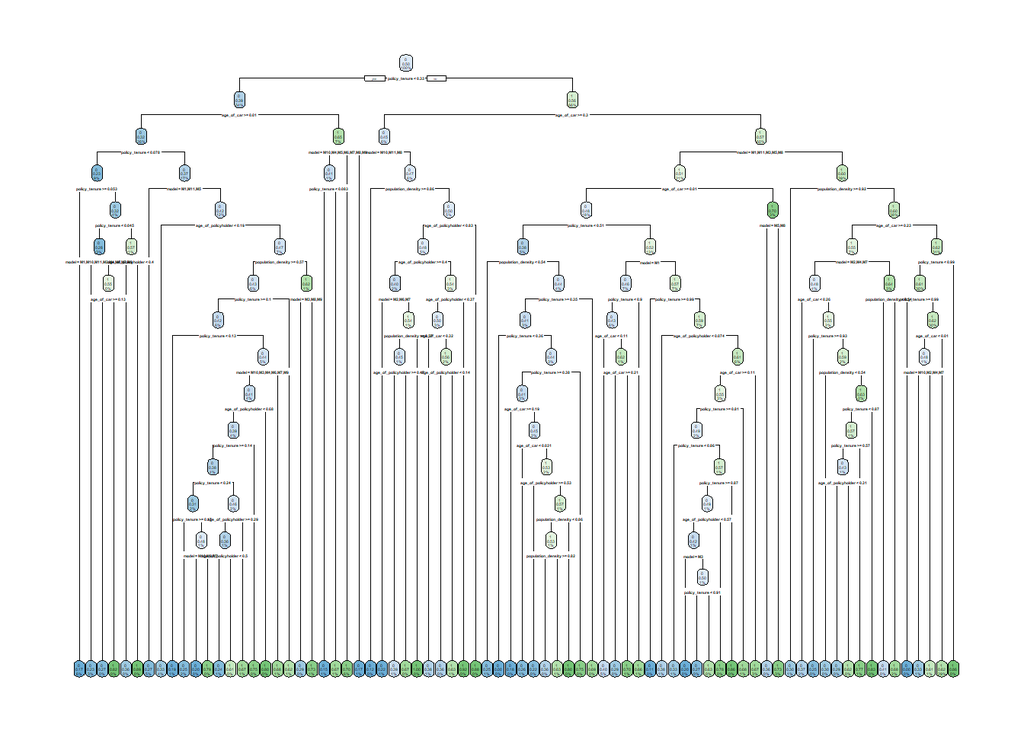

```r
tree_fit <- rpart(train_downsampling$is_claim ~.,
                  data = train_downsampling, # Data set
                  cp = 0.001,
                  method = "class") # Method: Classification


rpart.plot(tree_fit) # Plot the resulting tree
```

```r
# Predict values for validation set
pred_tree_v_tr <- predict(tree_fit,
                         cars_validation[,c(-6)],
                         type ="class")
```

#### Finding the optimal CP

```r
# Find the best cp with minimal xerror ||  /!\ code may need to be improved
cp_minimal <- tree_fit$cptable[which.min(
  tree_fit$cptable[,"CP"]), # Take lowest cp and Take lowest xerror
  1]# CP column

pruned.tree <- prune(tree_fit, cp= cp_minimal) # Prune the train model with lowest cp
```

#### Finding best size tree

```r
# Cross-validation

table_cp <- pruned.tree$cptable # Save cps

# DOES SOMEONE HAVE A BETTER METHOD ?
rows_small_errors_std <- head(order(table_cp[,5]),6) # Know the rows (folds) having  the smallest standard errors of the estimates

table_error <- matrix(table_cp[,4] + table_cp[,5]) # Sum the std error and the error

table_error <- cbind(table_cp[,1], # Include CP
                     table_cp[,2], # Include nsplit
                     table_error,  # Error + std error
                     table_cp[,5]) # Std error

rows_small_errors_std <- head(sort(table_error[,4]),6) # Know the rows (folds) having  the smallest std error
rows_small_errors <- head(sort(table_error[,3]),6) # Display the smallest standard errors

rows_small_errors_std # Display and chose the best size
```

```
##         16         17         10         11         12         18
## 0.01461348 0.01461348 0.01461631 0.01461913 0.01462053 0.01462612
```

```r
rows_small_errors # Display
```

```
##        16        17        10        11        12        18
## 0.8065778 0.8065778 0.8074735 0.8083691 0.8088170 0.8106083
```

```r
kable(table_cp)
```

| CP | nsplit | rel error | xerror | xstd |
| --- | --- | --- | --- | --- |
| 0.1464286 | 0 | 1.0000000 | 1.0392857 | 0.0149288 |
| 0.0441964 | 1 | 0.8535714 | 0.8625000 | 0.0147985 |
| 0.0133929 | 2 | 0.8093750 | 0.8147321 | 0.0146817 |
| 0.0074405 | 3 | 0.7959821 | 0.8183036 | 0.0146917 |
| 0.0049107 | 8 | 0.7535714 | 0.8071429 | 0.0146599 |
| 0.0044643 | 9 | 0.7486607 | 0.8053571 | 0.0146546 |
| 0.0040179 | 10 | 0.7441964 | 0.8017857 | 0.0146439 |
| 0.0035714 | 11 | 0.7401786 | 0.8058036 | 0.0146559 |
| 0.0031250 | 12 | 0.7366071 | 0.8004464 | 0.0146399 |
| 0.0028274 | 14 | 0.7303571 | 0.7928571 | 0.0146163 |
| 0.0026786 | 17 | 0.7218750 | 0.7937500 | 0.0146191 |
| 0.0018973 | 18 | 0.7191964 | 0.7941964 | 0.0146205 |
| 0.0017857 | 25 | 0.7040179 | 0.8049107 | 0.0146533 |
| 0.0015625 | 28 | 0.6986607 | 0.8008929 | 0.0146412 |
| 0.0014881 | 32 | 0.6915179 | 0.7991071 | 0.0146358 |
| 0.0014509 | 35 | 0.6870536 | 0.7919643 | 0.0146135 |
| 0.0013393 | 50 | 0.6584821 | 0.7919643 | 0.0146135 |
| 0.0012500 | 56 | 0.6504464 | 0.7959821 | 0.0146261 |
| 0.0011161 | 61 | 0.6441964 | 0.8107143 | 0.0146703 |
| 0.0010000 | 75 | 0.6263393 | 0.8107143 | 0.0146703 |

```r
best_cp <- table_cp[as.integer(names(rows_small_errors)[1]),1]
```

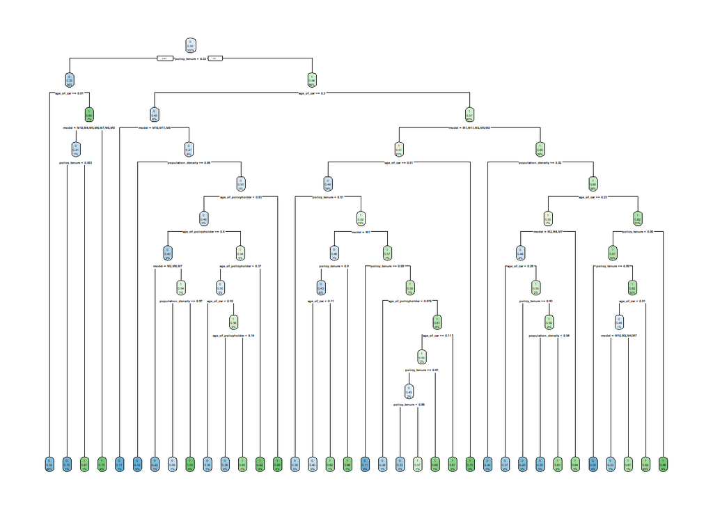

```r
pruned.tree <- prune(tree_fit, cp = best_cp) # Prune the train model with best cp

rpart.plot(pruned.tree) # Plot the tree with best size
```

```r
sum(pruned.tree$frame$ncompete == 0) # Number of leaves
```

```
## [1] 36
```

### Performance evaluation

```r
# Confusion matrix for classification tree with validation set
conf_matrix_tree_v <- confusionMatrix(
  pred_tree_v_tr,
  factor(cars_validation$is_claim),
  positive = "1")
conf_matrix_tree_v
```

```
## Confusion Matrix and Statistics
##
##           Reference
## Prediction     0     1
##          0  9001   384
##          1 12928  1124
##
##                Accuracy : 0.432
##                  95% CI : (0.4257, 0.4384)
##     No Information Rate : 0.9357
##     P-Value [Acc > NIR] : 1
##
##                   Kappa : 0.032
##
##  Mcnemar's Test P-Value : <2e-16
##
##             Sensitivity : 0.74536
##             Specificity : 0.41046
##          Pos Pred Value : 0.07999
##          Neg Pred Value : 0.95908
##              Prevalence : 0.06434
##          Detection Rate : 0.04796
##    Detection Prevalence : 0.59956
##       Balanced Accuracy : 0.57791
##
##        'Positive' Class : 1
##
```

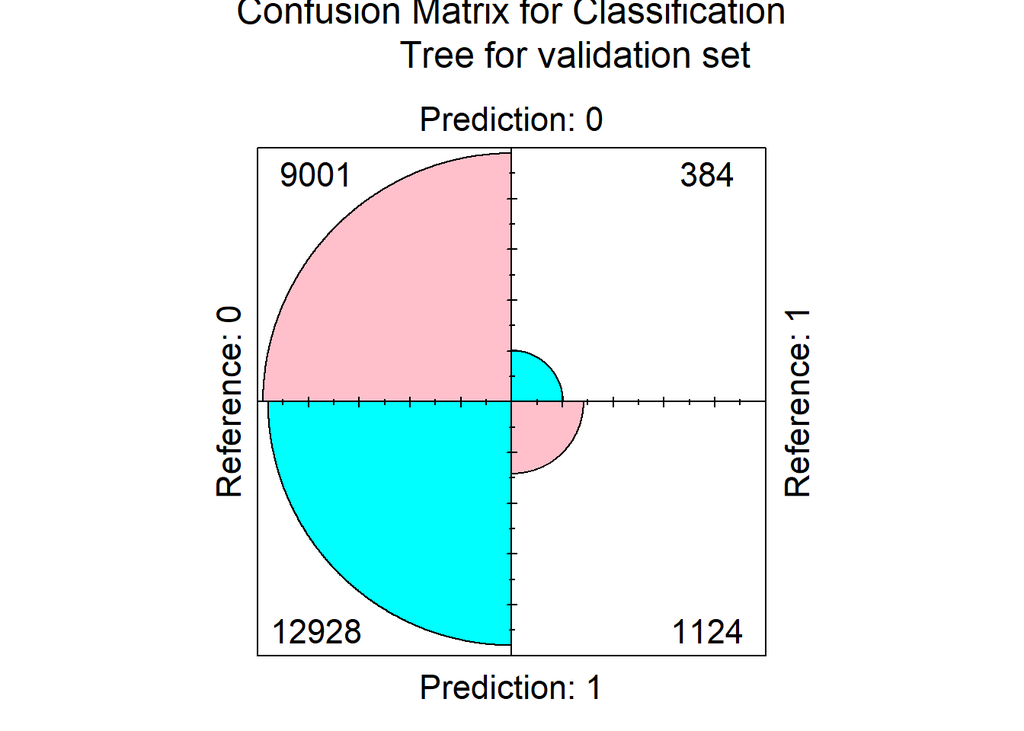

```r
# plot confusion matrix
fourfoldplot(conf_matrix_tree_v$table,
             color = c("cyan", "pink"),
             conf.level = 0,
             margin = 1,
             main = "Confusion Matrix for Classification
             Tree for validation set")
```

```r
# Prediction on Validation data
pred_tree_v_pruned <- predict(pruned.tree, # Pruned tree
                         cars_validation[,c(-16)],# Validation set
                         type ="class")

# Confusion matrix for classification tree with validation set
conf_matrix_tree_v <- confusionMatrix(
  pred_tree_v_pruned,
  factor(cars_validation$is_claim),
  positive = "1")
conf_matrix_tree_v
```

```
## Confusion Matrix and Statistics
##
##           Reference
## Prediction     0     1
##          0  9988   429
##          1 11941  1079
##
##                Accuracy : 0.4722
##                  95% CI : (0.4658, 0.4786)
##     No Information Rate : 0.9357
##     P-Value [Acc > NIR] : 1
##
##                   Kappa : 0.0375
##
##  Mcnemar's Test P-Value : <2e-16
##
##             Sensitivity : 0.71552
##             Specificity : 0.45547
##          Pos Pred Value : 0.08287
##          Neg Pred Value : 0.95882
##              Prevalence : 0.06434
##          Detection Rate : 0.04604
##    Detection Prevalence : 0.55553
##       Balanced Accuracy : 0.58549
##
##        'Positive' Class : 1
##
```

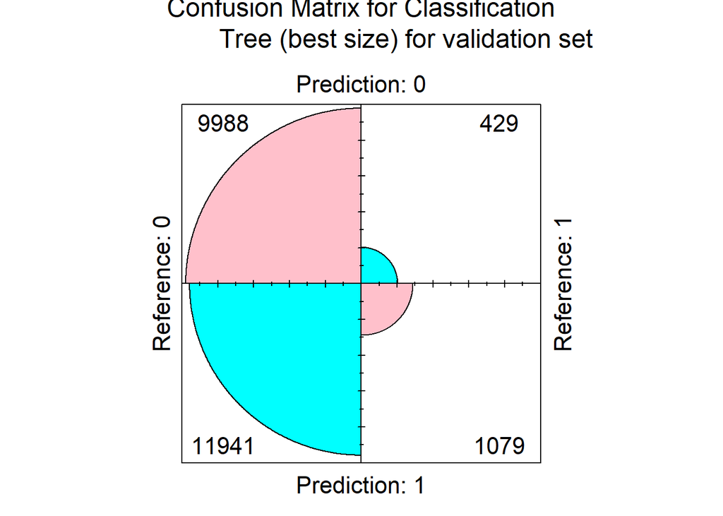

```r
# plot confusion matrix
fourfoldplot(conf_matrix_tree_v$table,
             color = c("cyan", "pink"),
             conf.level = 0,
             margin = 1,
             main = "Confusion Matrix for Classification
             Tree (best size) for validation set")
```

#### Lift Chart

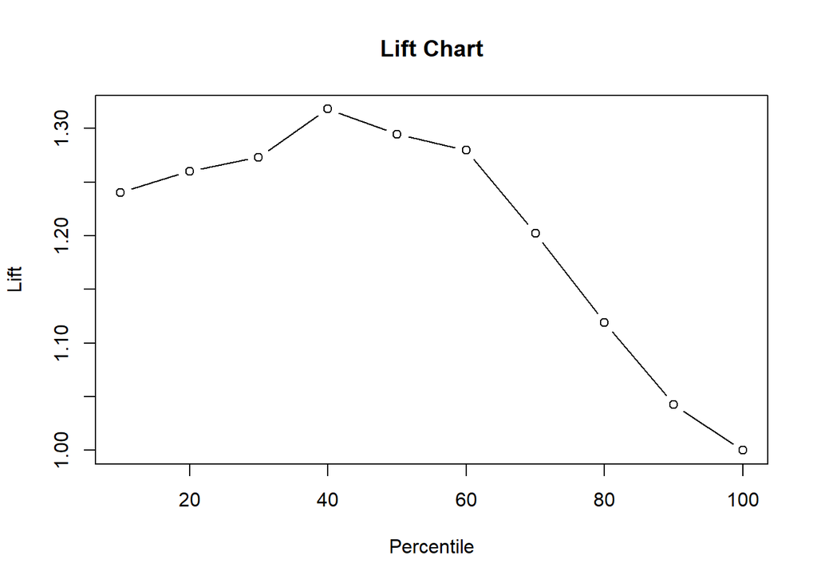

```r
#Getting the probabilities from the model
tree.outcome <- as.data.frame(predict(pruned.tree, # Pruned tree
                         cars_validation[,c(-16)],# Validation set
                         type ="prob"))[,2]


#Lift chart plot
liftChart(tree.outcome,  factor(cars_validation$is_claim))
```

```r
topDecileLift(tree.outcome,  factor(cars_validation$is_claim))
```

```
## [1] 1.240424
```

## KNN

### Data transformation

```r
# Add dummy variables
cars_final$model <- as.factor(cars_final$model)                       # change variable format to factor

dummies <- dummyVars(~ ., data = cars_final)                             # create object for dummy variables
cars_final_dummy <- as.data.frame(predict(dummies,
                                          newdata = cars_final))      # apply dummies to data

cars_final$is_claim <- as.factor(cars_final$is_claim)                # change variable format to factor
cars_final_dummy$is_claim <- as.factor(cars_final_dummy$is_claim)

head(cars_final_dummy)                                                  # resulting in 11
```

```
##   policy_tenure age_of_car age_of_policyholder population_density model.M1
## 1     0.3681298       0.05           0.6442308          0.5141315        1
## 2     0.4805800       0.02           0.3750000          0.8192361        1
## 3     0.6014574       0.02           0.3846154          0.4775735        1
## 4     0.6439038       0.11           0.4326923          0.7790792        0
## 5     0.4259022       0.11           0.6346154          0.8647506        0
## 6     0.7288679       0.07           0.5192308          0.6878563        0
##   model.M10 model.M11 model.M2 model.M3 model.M4 model.M5 model.M6 model.M7
## 1         0         0        0        0        0        0        0        0
## 2         0         0        0        0        0        0        0        0
## 3         0         0        0        0        0        0        0        0
## 4         0         0        1        0        0        0        0        0
## 5         0         0        0        1        0        0        0        0
## 6         0         0        0        0        1        0        0        0
##   model.M8 model.M9 is_claim
## 1        0        0        0
## 2        0        0        0
## 3        0        0        0
## 4        0        0        0
## 5        0        0        0
## 6        0        0        0
```

```r
str(cars_final_dummy)
```

```
## 'data.frame':    58592 obs. of  16 variables:
##  $ policy_tenure      : num  0.368 0.481 0.601 0.644 0.426 ...
##  $ age_of_car         : num  0.05 0.02 0.02 0.11 0.11 0.07 0.16 0.14 0.07 0.04 ...
##  $ age_of_policyholder: num  0.644 0.375 0.385 0.433 0.635 ...
##  $ population_density : num  0.514 0.819 0.478 0.779 0.865 ...
##  $ model.M1           : num  1 1 1 0 0 0 0 0 0 0 ...
##  $ model.M10          : num  0 0 0 0 0 0 0 0 0 0 ...
##  $ model.M11          : num  0 0 0 0 0 0 0 0 0 0 ...
##  $ model.M2           : num  0 0 0 1 0 0 0 0 0 0 ...
##  $ model.M3           : num  0 0 0 0 1 0 0 0 0 0 ...
##  $ model.M4           : num  0 0 0 0 0 1 0 0 1 0 ...
##  $ model.M5           : num  0 0 0 0 0 0 1 0 0 0 ...
##  $ model.M6           : num  0 0 0 0 0 0 0 1 0 0 ...
##  $ model.M7           : num  0 0 0 0 0 0 0 0 0 1 ...
##  $ model.M8           : num  0 0 0 0 0 0 0 0 0 0 ...
##  $ model.M9           : num  0 0 0 0 0 0 0 0 0 0 ...
##  $ is_claim           : Factor w/ 2 levels "0","1": 1 1 1 1 1 1 1 1 1 1 ...
```

```r
train_dummy <- cars_final_dummy[index,] # training set with dummies
valid_dummy <- cars_final_dummy[-index,] #validation set with dummies
train_dummy_downsampled <- downSample(train_dummy[,-16],
                                      train_dummy$is_claim,yname = "is_claim") # undersampling for having same probation

# Normalizing data
train_dummy_downsampled[,c(1:4)] <- lapply(train_dummy_downsampled[,c(1:4)], normalizing)

valid_dummy[,c(1:4)] <- lapply(valid_dummy[,c(1:4)], normalizing)
```

#### Loop for finding the optimum k for each measurement

```r
set.seed(1)
# Find optimal k

# Data frame for k from 1 to 50 and respective accuracy
accuracy <- data.frame(k = seq(1, 50, 1),
                       overallaccuracy = rep(0, 50))

# Use for loop to find k with highest accuracy
for (i in 1:50) {
  knn.pred<-knn(train_dummy_downsampled[,-16],
                valid_dummy[,-16],
                cl=train_dummy_downsampled[,16],k=i)
  accuracy[i,2]<-confusionMatrix(knn.pred,
                                 valid_dummy[,16])$overall[1]
}
# Data frame for k from 1 to 50 and respective specificity
Specificity <-  data.frame(k = seq(1, 50, 1),
                           overallspecificity = rep(0, 50))

# Use for loop to find k with highest specificity
for (i in 1:50) {
  knn.pred<-knn(train_dummy_downsampled[,-16],
                valid_dummy[,-16],
                cl=train_dummy_downsampled[,16],k=i)
  Specificity[i,2]<-confusionMatrix(knn.pred,
                                    valid_dummy[,16])$byClass[2]
}
# Data frame for k from 1 to 50 and respective Sensitivity
Sensitivity  <-  data.frame(k = seq(1, 50, 1),
                            overallSensitivity  = rep(0, 50))

# Use for loop to find k with highest Sensitivity
for (i in 1:50) {
  knn.pred<-knn(train_dummy_downsampled[,-16],
                valid_dummy[,-16],
                cl=train_dummy_downsampled[,16],k=i)
  Sensitivity[i,2]<-confusionMatrix(knn.pred,
                                    valid_dummy[,16])$byClass[1]
}
```

#### Max k

```r
which(accuracy[,2] == max(accuracy[,2]))   # max accuracy
```

```
## [1] 2
```

```r
which(Specificity[,2] == max(Specificity[,2]))   # max specificity
```

```
## [1] 41
```

```r
which(Sensitivity[,2] == max(Sensitivity[,2]))   # max specificity
```

```
## [1] 1
```

#### Plotting results

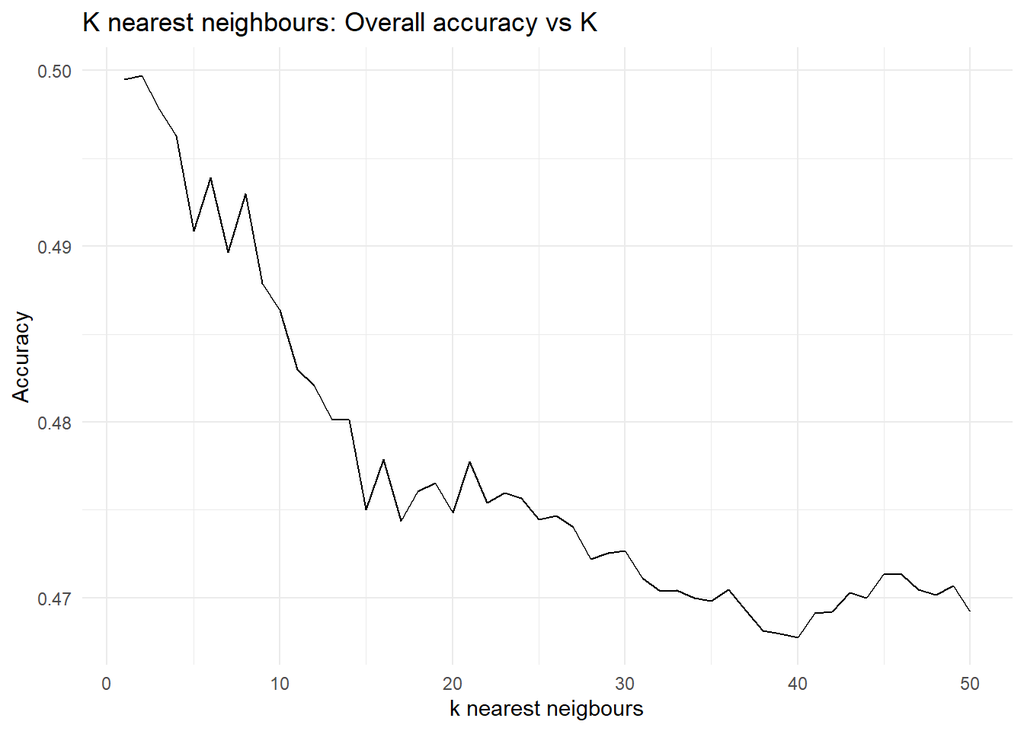

```r
# Plot accuracy for different k
ggplot(accuracy, aes(k, overallaccuracy)) +
  geom_line() +
  theme_minimal() +
  labs (title = "K nearest neighbours: Overall accuracy vs K",
        y = "Accuracy",
        x = "k nearest neigbours" )
```

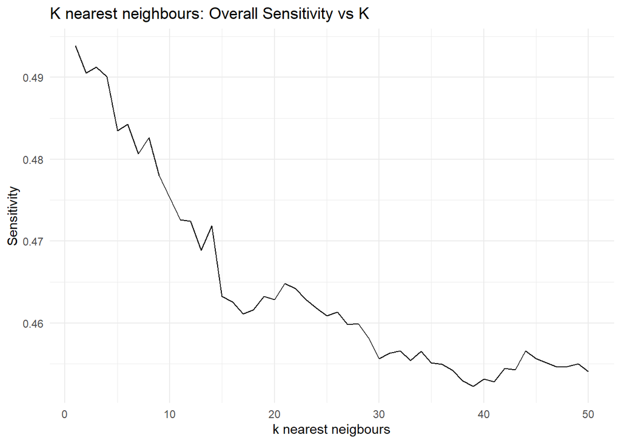

```r
# Plot Sensitivity for different k
ggplot(Sensitivity, aes(k, overallSensitivity)) +
  geom_line() +
  theme_minimal() +
  labs (title = "K nearest neighbours: Overall Sensitivity vs K",
        y = "Sensitivity",
        x = "k nearest neigbours" )
```

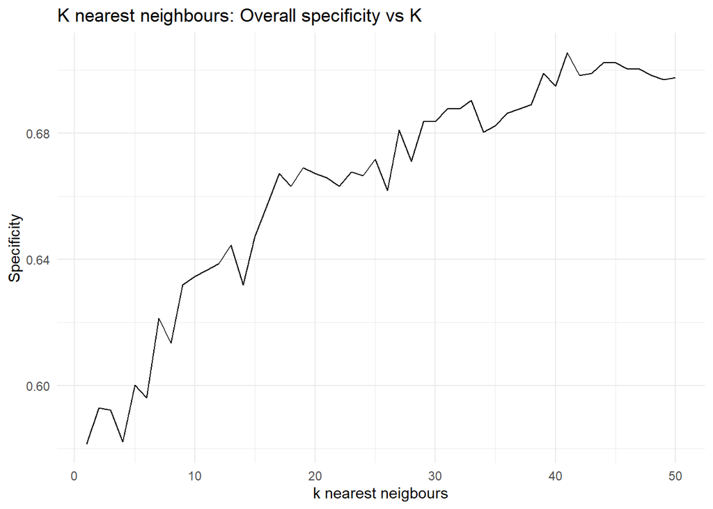

```r
# Plot specificity for different k
ggplot(Specificity, aes(k, overallspecificity)) +
  geom_line() +
  theme_minimal() +
  labs (title = "K nearest neighbours: Overall specificity vs K",
        y = "Specificity",
        x = "k nearest neigbours" )
```

#### Prediction and confusion matrix for knn

```r
knn.pred.valid <- knn(train_dummy_downsampled[, -16], valid_dummy[, -16], cl = train_dummy_downsampled[, 16], k = 41 ,prob = T)     #prediction on validation data using best k=6
cmk <- confusionMatrix(knn.pred.valid,valid_dummy[,16])    #confusion matrix
cmk$byClass[2]
```

```
## Specificity
##   0.7055703
```

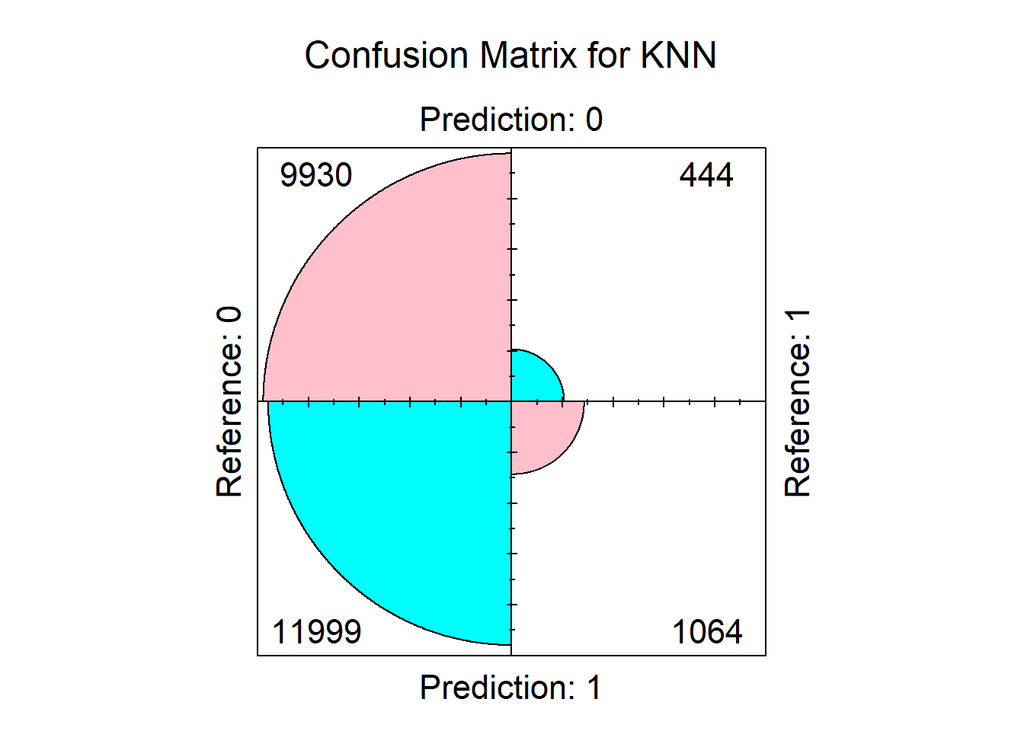

```r
fourfoldplot(cmk$table, color = c("cyan", "pink"),
             conf.level = 0, margin = 1, main = "Confusion Matrix for KNN")     # plot confusion ma
```

```r
cmk
```

```
## Confusion Matrix and Statistics
##
##           Reference
## Prediction     0     1
##          0  9930   444
##          1 11999  1064
##
##                Accuracy : 0.4691
##                  95% CI : (0.4627, 0.4755)
##     No Information Rate : 0.9357
##     P-Value [Acc > NIR] : 1
##
##                   Kappa : 0.0347
##
##  Mcnemar's Test P-Value : <2e-16
##
##             Sensitivity : 0.45283
##             Specificity : 0.70557
##          Pos Pred Value : 0.95720
##          Neg Pred Value : 0.08145
##              Prevalence : 0.93566
##          Detection Rate : 0.42369
##    Detection Prevalence : 0.44263
##       Balanced Accuracy : 0.57920
##
##        'Positive' Class : 0
##
```

#### Lift Chart

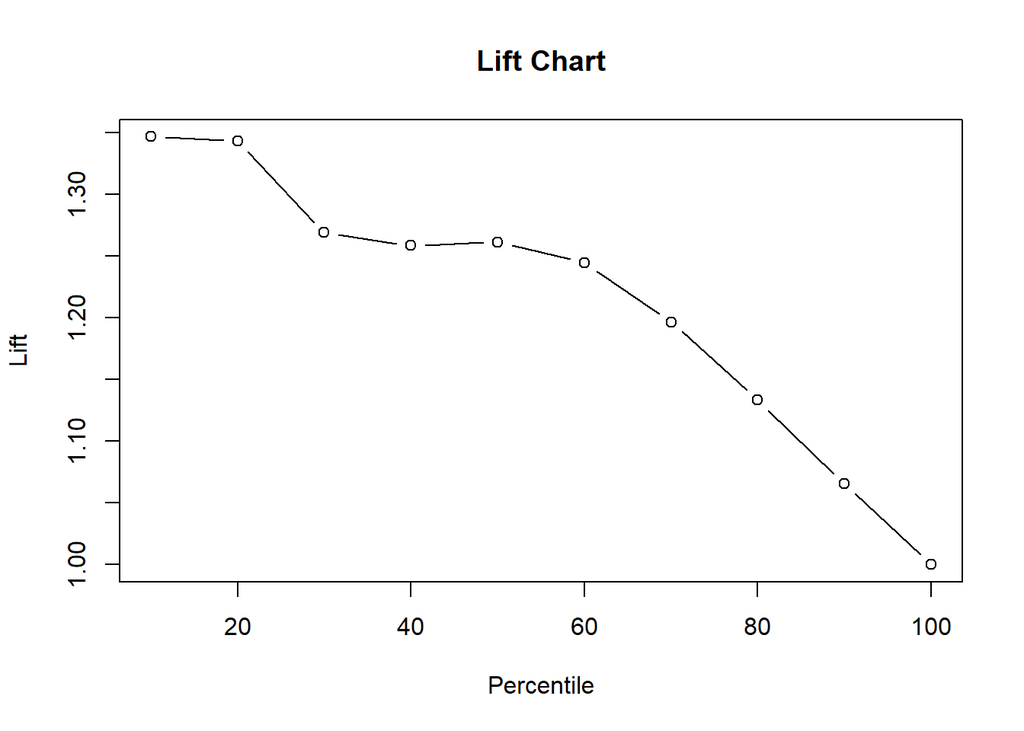

```r
#Extracting the probabilities
knn_outcome <- as.data.table(cbind(as.data.table(knn.pred.valid), knn_prob = attr(knn.pred.valid, "prob")))

# Adjusting probabilities
knn_outcome[knn.pred.valid != 1, knn_prob := 1 - knn_prob]

# plot
liftChart(knn_outcome$knn_prob, factor(valid_dummy$is_claim))
```

```r
topDecileLift(knn_outcome$knn_prob, factor(valid_dummy$is_claim))
```

[output not shown]

.

## Neural Network

### Method application

#### 1 hidden layer and 2 nodes

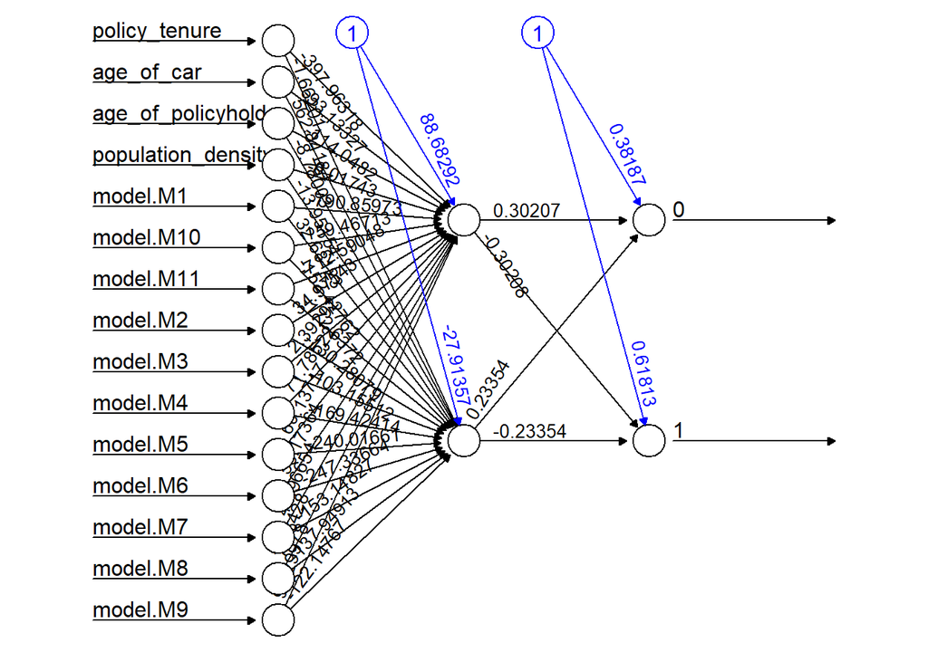

```r
# Run Neural Network (N.N.) with 1 hidden layer and 2 nodes
nn_1H_2N <- neuralnet(is_claim ~ .,
                    data = train_dummy_downsampled,
                    hidden = 2) # 1 hidden layer of 2 nodes

plot(nn_1H_2N, rep="best")
```

```r
# Predict the output on validation set
validation_prediction_1H_2N <- predict(nn_1H_2N,
                                      valid_dummy[,-16],
                                      type = "class")

validation_prediction_1H_2N_binary <-
  ifelse(validation_prediction_1H_2N[,1]
         >= 0.5, 1, 0) # Transform probabilities as binary outcome
```

#### 1 hidden layer and 4 nodes

We had to comment out the code related to the neural network with 4 nodes because it leads to an error most of the time, making the knitting impossible

```r
# run Neural Network (N.N.) with 1 hidden layer and 4 nodes
# nn_1H_4N <- neuralnet(is_claim ~ .,
#                    data = train_dummy_downsampled,
#                    hidden = c(4)) # 1 hidden layer of 4 nodes





# plot(nn_1H_4N, rep="best") # plots the neural net with 4 nodes


# Predict the output on validation set
# validation_prediction_1H_4N <- predict(nn_1H_4N,
#                                      valid_dummy[,-16],
#                                      type = "class")
#
# validation_prediction_1H_4N_binary <-
#  ifelse(validation_prediction_1H_4N[,1]
#         >= 0.5, 1, 0) # Transform probabilities as binary outcome
```

### Performance evaluation

```r
# Confusion matrix for classification tree with validation set
conf_matrix_1H2N_valid <- confusionMatrix(
  factor(validation_prediction_1H_2N_binary),
  factor(valid_dummy$is_claim), # change dataset
  positive = "1")

conf_matrix_1H2N_valid
```

```
## Confusion Matrix and Statistics
##
##           Reference
## Prediction     0     1
##          0 13299  1181
##          1  8630   327
##
##                Accuracy : 0.5814
##                  95% CI : (0.575, 0.5877)
##     No Information Rate : 0.9357
##     P-Value [Acc > NIR] : 1
##
##                   Kappa : -0.0535
##
##  Mcnemar's Test P-Value : <2e-16
##
##             Sensitivity : 0.21684
##             Specificity : 0.60646
##          Pos Pred Value : 0.03651
##          Neg Pred Value : 0.91844
##              Prevalence : 0.06434
##          Detection Rate : 0.01395
##    Detection Prevalence : 0.38217
##       Balanced Accuracy : 0.41165
##
##        'Positive' Class : 1
##
```

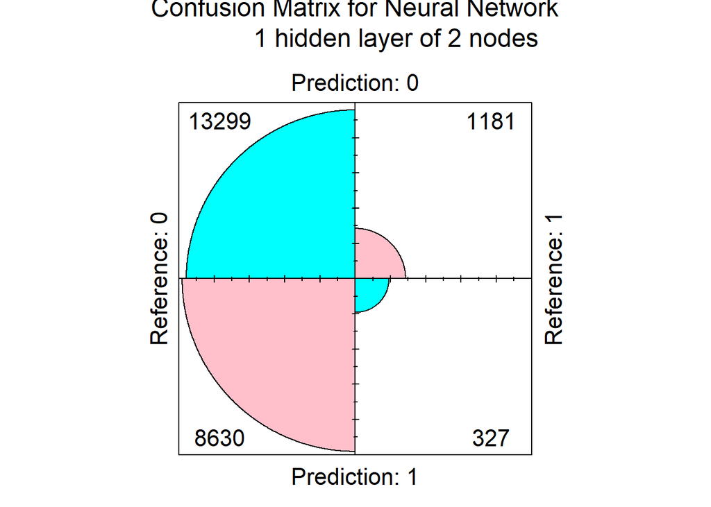

```r
# plot confusion matrix
fourfoldplot(conf_matrix_1H2N_valid$table,
            color = c("cyan", "pink"),
            conf.level = 0,
            margin = 1,
            main = "Confusion Matrix for Neural Network
            1 hidden layer of 2 nodes")
```

```r
# Confusion matrix for classification tree with validation set
# conf_matrix_1H4N_valid <- confusionMatrix(
#   factor(validation_prediction_1H_4N_binary),
#   factor(valid_dummy$is_claim), # change dataset
#   positive = "1")
#
# conf_matrix_1H4N_valid

# plot confusion matrix
# fourfoldplot(conf_matrix_1H4N_valid$table,
#           color = c("cyan", "pink"),
#           conf.level = 0,
#           margin = 1,
#           main = "Confusion Matrix for Neural Network
#           1 hidden layer of 4 nodes")
```

## Logistic Regression

### Method Application

All variables logistic regression

```r
cars.lg <- glm(is_claim ~., data= train_downsampling, family=binomial(link="logit"))

summary(cars.lg) # Displaying the resulting model
```

```
##
## Call:
## glm(formula = is_claim ~ ., family = binomial(link = "logit"),
##     data = train_downsampling)
##
## Deviance Residuals:
##     Min       1Q   Median       3Q      Max
## -1.6217  -1.1485   0.0561   1.1390   1.8354
##
## Coefficients:
##                     Estimate Std. Error z value Pr(>|z|)
## (Intercept)         -0.26571    0.15201  -1.748   0.0805 .
## policy_tenure        0.99056    0.09941   9.965  < 2e-16 ***
## age_of_car          -1.85521    0.31159  -5.954 2.62e-09 ***
## age_of_policyholder  0.12697    0.14709   0.863   0.3880
## population_density  -0.19614    0.18370  -1.068   0.2856
## modelM10            -0.06149    0.23780  -0.259   0.7959
## modelM11            -0.38564    0.41248  -0.935   0.3498
## modelM2              0.50452    0.23030   2.191   0.0285 *
## modelM3             -0.13328    0.17131  -0.778   0.4366
## modelM4              0.14300    0.09739   1.468   0.1420
## modelM5              0.11491    0.19127   0.601   0.5480
## modelM6              0.17503    0.09725   1.800   0.0719 .
## modelM7              0.12728    0.15240   0.835   0.4036
## modelM8             -0.06633    0.13543  -0.490   0.6243
## modelM9              0.09928    0.17630   0.563   0.5734
## ---
## Signif. codes:  0 '***' 0.001 '**' 0.01 '*' 0.05 '.' 0.1 ' ' 1
##
## (Dispersion parameter for binomial family taken to be 1)
##
##     Null deviance: 6210.6  on 4479  degrees of freedom
## Residual deviance: 6057.7  on 4465  degrees of freedom
## AIC: 6087.7
##
## Number of Fisher Scoring iterations: 4
```

Plot of residuals

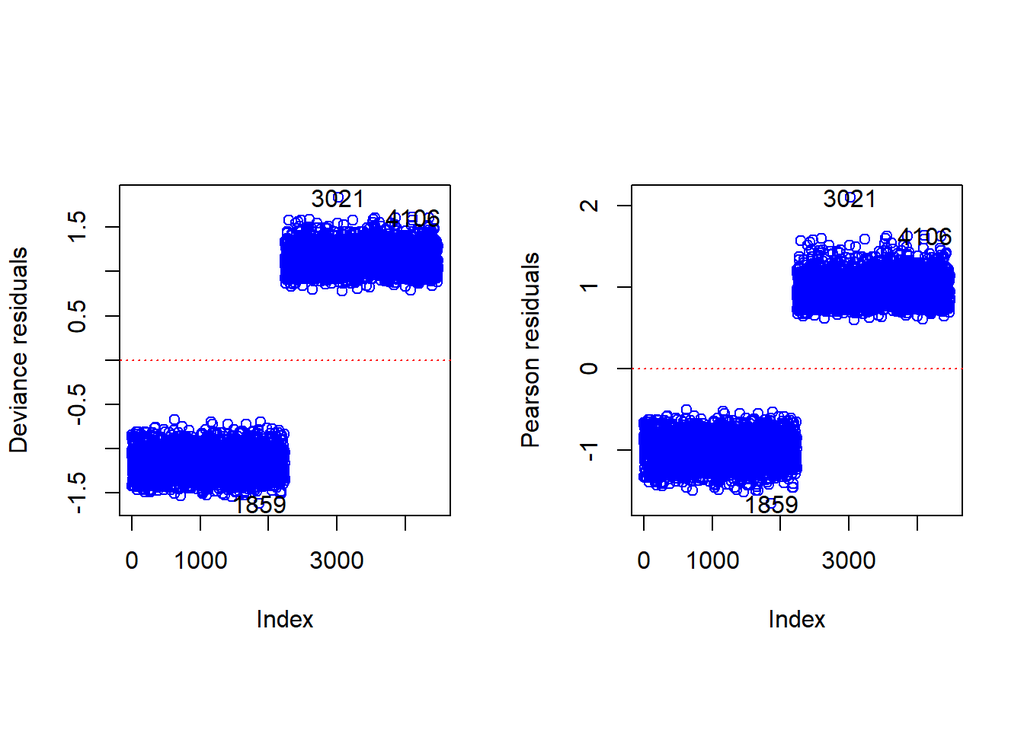

```r
PlotResidLogist(cars.lg) # Deviance residuals
```

analysis of the deviance with anova

```r
anova(cars.lg, test="Chisq")
```

```
## Analysis of Deviance Table
##
## Model: binomial, link: logit
##
## Response: is_claim
##
## Terms added sequentially (first to last)
##
##
##                     Df Deviance Resid. Df Resid. Dev  Pr(>Chi)
## NULL                                 4479     6210.6
## policy_tenure        1  103.251      4478     6107.3 < 2.2e-16 ***
## age_of_car           1   34.170      4477     6073.2 5.049e-09 ***
## age_of_policyholder  1    1.042      4476     6072.1    0.3074
## population_density   1    1.341      4475     6070.8    0.2469
## model               10   13.142      4465     6057.7    0.2158
## ---
## Signif. codes:  0 '***' 0.001 '**' 0.01 '*' 0.05 '.' 0.1 ' ' 1
```

backward selection

```r
cars_glm_back <- step(cars.lg, direction = "backward") # Model with backward selection
```

```
## Start:  AIC=6087.65
## is_claim ~ policy_tenure + age_of_car + age_of_policyholder +
##     population_density + model
##
##                       Df Deviance    AIC
## - model               10   6070.8 6080.8
## - age_of_policyholder  1   6058.4 6086.4
## - population_density   1   6058.8 6086.8
## <none>                     6057.7 6087.7
## - age_of_car           1   6093.8 6121.8
## - policy_tenure        1   6158.9 6186.9
##
## Step:  AIC=6080.79
## is_claim ~ policy_tenure + age_of_car + age_of_policyholder +
##     population_density
##
##                       Df Deviance    AIC
## - age_of_policyholder  1   6071.9 6079.9
## - population_density   1   6072.1 6080.1
## <none>                     6070.8 6080.8
## - age_of_car           1   6105.1 6113.1
## - policy_tenure        1   6185.6 6193.6
##
## Step:  AIC=6079.87
## is_claim ~ policy_tenure + age_of_car + population_density
##
##                      Df Deviance    AIC
## - population_density  1   6073.2 6079.2
## <none>                    6071.9 6079.9
## - age_of_car          1   6106.4 6112.4
## - policy_tenure       1   6191.9 6197.9
##
## Step:  AIC=6079.18
## is_claim ~ policy_tenure + age_of_car
##
##                 Df Deviance    AIC
## <none>               6073.2 6079.2
## - age_of_car     1   6107.3 6111.3
## - policy_tenure  1   6194.7 6198.7
```

```r
summary(cars_glm_back)
```

```
##
## Call:
## glm(formula = is_claim ~ policy_tenure + age_of_car, family = binomial(link = "logit"),
##     data = train_downsampling)
##
## Deviance Residuals:
##     Min       1Q   Median       3Q      Max
## -1.4797  -1.1518   0.1053   1.1345   1.7990
##
## Coefficients:
##               Estimate Std. Error z value Pr(>|z|)
## (Intercept)   -0.33365    0.06430  -5.189 2.11e-07 ***
## policy_tenure  1.04187    0.09563  10.895  < 2e-16 ***
## age_of_car    -1.59893    0.27582  -5.797 6.75e-09 ***
## ---
## Signif. codes:  0 '***' 0.001 '**' 0.01 '*' 0.05 '.' 0.1 ' ' 1
##
## (Dispersion parameter for binomial family taken to be 1)
##
##     Null deviance: 6210.6  on 4479  degrees of freedom
## Residual deviance: 6073.2  on 4477  degrees of freedom
## AIC: 6079.2
##
## Number of Fisher Scoring iterations: 4
```

forward selection

```r
cars_glm_forward <- step(cars.lg, direction = "forward") # Model with forward selection
```

```
## Start:  AIC=6087.65
## is_claim ~ policy_tenure + age_of_car + age_of_policyholder +
##     population_density + model
```

```r
summary(cars_glm_forward)
```

```
##
## Call:
## glm(formula = is_claim ~ policy_tenure + age_of_car + age_of_policyholder +
##     population_density + model, family = binomial(link = "logit"),
##     data = train_downsampling)
##
## Deviance Residuals:
##     Min       1Q   Median       3Q      Max
## -1.6217  -1.1485   0.0561   1.1390   1.8354
##
## Coefficients:
##                     Estimate Std. Error z value Pr(>|z|)
## (Intercept)         -0.26571    0.15201  -1.748   0.0805 .
## policy_tenure        0.99056    0.09941   9.965  < 2e-16 ***
## age_of_car          -1.85521    0.31159  -5.954 2.62e-09 ***
## age_of_policyholder  0.12697    0.14709   0.863   0.3880
## population_density  -0.19614    0.18370  -1.068   0.2856
## modelM10            -0.06149    0.23780  -0.259   0.7959
## modelM11            -0.38564    0.41248  -0.935   0.3498
## modelM2              0.50452    0.23030   2.191   0.0285 *
## modelM3             -0.13328    0.17131  -0.778   0.4366
## modelM4              0.14300    0.09739   1.468   0.1420
## modelM5              0.11491    0.19127   0.601   0.5480
## modelM6              0.17503    0.09725   1.800   0.0719 .
## modelM7              0.12728    0.15240   0.835   0.4036
## modelM8             -0.06633    0.13543  -0.490   0.6243
## modelM9              0.09928    0.17630   0.563   0.5734
## ---
## Signif. codes:  0 '***' 0.001 '**' 0.01 '*' 0.05 '.' 0.1 ' ' 1
##
## (Dispersion parameter for binomial family taken to be 1)
##
##     Null deviance: 6210.6  on 4479  degrees of freedom
## Residual deviance: 6057.7  on 4465  degrees of freedom
## AIC: 6087.7
##
## Number of Fisher Scoring iterations: 4
```

backward+forward selection

```r
cars_glm_both <- step(cars.lg, direction = "both") # Forward and backward
```

```
## Start:  AIC=6087.65
## is_claim ~ policy_tenure + age_of_car + age_of_policyholder +
##     population_density + model
##
##                       Df Deviance    AIC
## - model               10   6070.8 6080.8
## - age_of_policyholder  1   6058.4 6086.4
## - population_density   1   6058.8 6086.8
## <none>                     6057.7 6087.7
## - age_of_car           1   6093.8 6121.8
## - policy_tenure        1   6158.9 6186.9
##
## Step:  AIC=6080.79
## is_claim ~ policy_tenure + age_of_car + age_of_policyholder +
##     population_density
##
##                       Df Deviance    AIC
## - age_of_policyholder  1   6071.9 6079.9
## - population_density   1   6072.1 6080.1
## <none>                     6070.8 6080.8
## + model               10   6057.7 6087.7
## - age_of_car           1   6105.1 6113.1
## - policy_tenure        1   6185.6 6193.6
##
## Step:  AIC=6079.87
## is_claim ~ policy_tenure + age_of_car + population_density
##
##                       Df Deviance    AIC
## - population_density   1   6073.2 6079.2
## <none>                     6071.9 6079.9
## + age_of_policyholder  1   6070.8 6080.8
## + model               10   6058.4 6086.4
## - age_of_car           1   6106.4 6112.4
## - policy_tenure        1   6191.9 6197.9
##
## Step:  AIC=6079.18
## is_claim ~ policy_tenure + age_of_car
##
##                       Df Deviance    AIC
## <none>                     6073.2 6079.2
## + population_density   1   6071.9 6079.9
## + age_of_policyholder  1   6072.1 6080.1
## + model               10   6059.5 6085.5
## - age_of_car           1   6107.3 6111.3
## - policy_tenure        1   6194.7 6198.7
```

```r
summary(cars_glm_both)
```

```
##
## Call:
## glm(formula = is_claim ~ policy_tenure + age_of_car, family = binomial(link = "logit"),
##     data = train_downsampling)
##
## Deviance Residuals:
##     Min       1Q   Median       3Q      Max
## -1.4797  -1.1518   0.1053   1.1345   1.7990
##
## Coefficients:
##               Estimate Std. Error z value Pr(>|z|)
## (Intercept)   -0.33365    0.06430  -5.189 2.11e-07 ***
## policy_tenure  1.04187    0.09563  10.895  < 2e-16 ***
## age_of_car    -1.59893    0.27582  -5.797 6.75e-09 ***
## ---
## Signif. codes:  0 '***' 0.001 '**' 0.01 '*' 0.05 '.' 0.1 ' ' 1
##
## (Dispersion parameter for binomial family taken to be 1)
##
##     Null deviance: 6210.6  on 4479  degrees of freedom
## Residual deviance: 6073.2  on 4477  degrees of freedom
## AIC: 6079.2
##
## Number of Fisher Scoring iterations: 4
```

### Performance Evaluation

Confusion Matrix for logistic regression with all variables

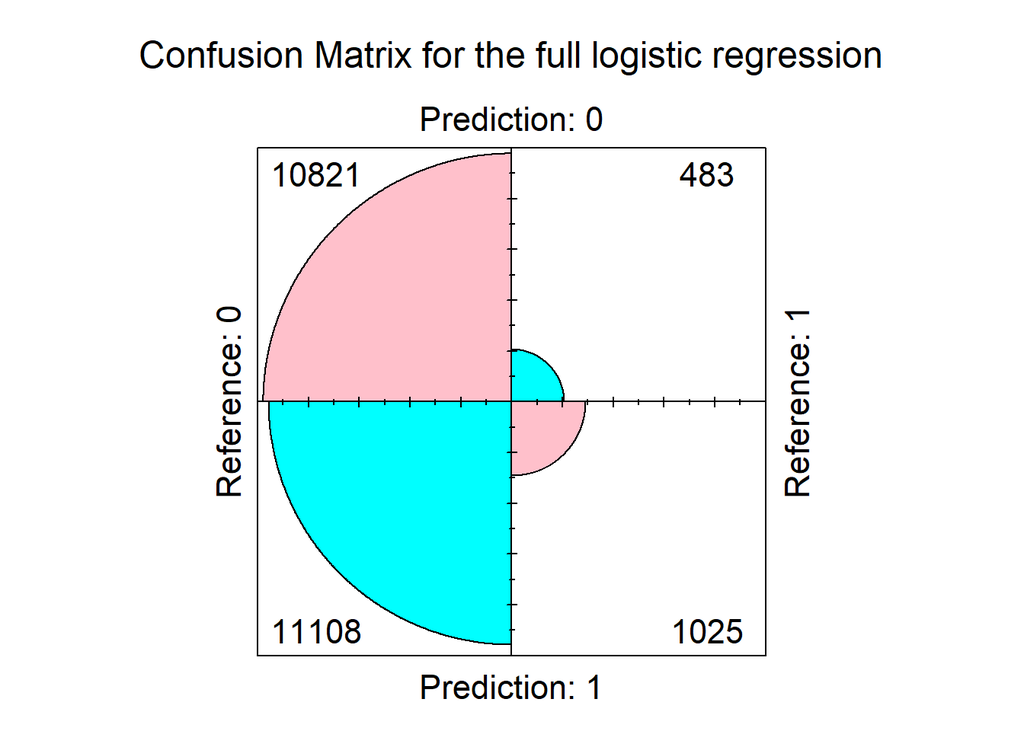

```r
# Full model
pred_logi <- predict(cars.lg, newdata = cars_validation[,-16], type = "response")

# 50% cutoff
logi_outcome <- as.data.table(pred_logi)
logi_outcome <- ifelse(logi_outcome > 0.5, 1, 0)


#Confusion Matrix
cm1 <- confusionMatrix(
  factor(logi_outcome),
  factor(cars_validation$is_claim),
  positive = "1")
#Plot
fourfoldplot(cm1$table,
             color = c("cyan", "pink"),
             conf.level = 0,
             margin = 1,
             main = "Confusion Matrix for the full logistic regression")
```

Confusion Matrix for logistic regression with all variables and 55% cutoff

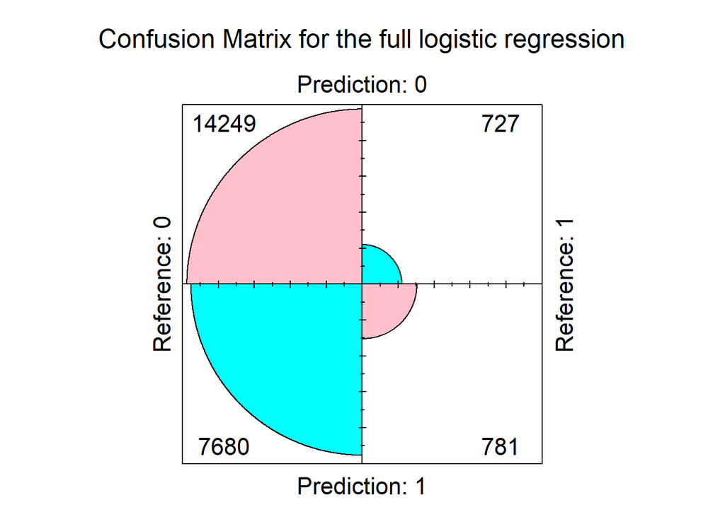

```r
# cutoff at probability of 0.55
logi_outcome <- as.data.table(pred_logi)
logi_outcome <- ifelse(logi_outcome > 0.55, 1, 0)

#Confusion Matrix
cm2 <- confusionMatrix(
  factor(logi_outcome),
  factor(cars_validation$is_claim),
  positive = "1")
#Plot
fourfoldplot(cm2$table,
             color = c("cyan", "pink"),
             conf.level = 0,
             margin = 1,
             main = "Confusion Matrix for the full logistic regression")
```

Confusion matrix for logistic regression with reduced number of variables

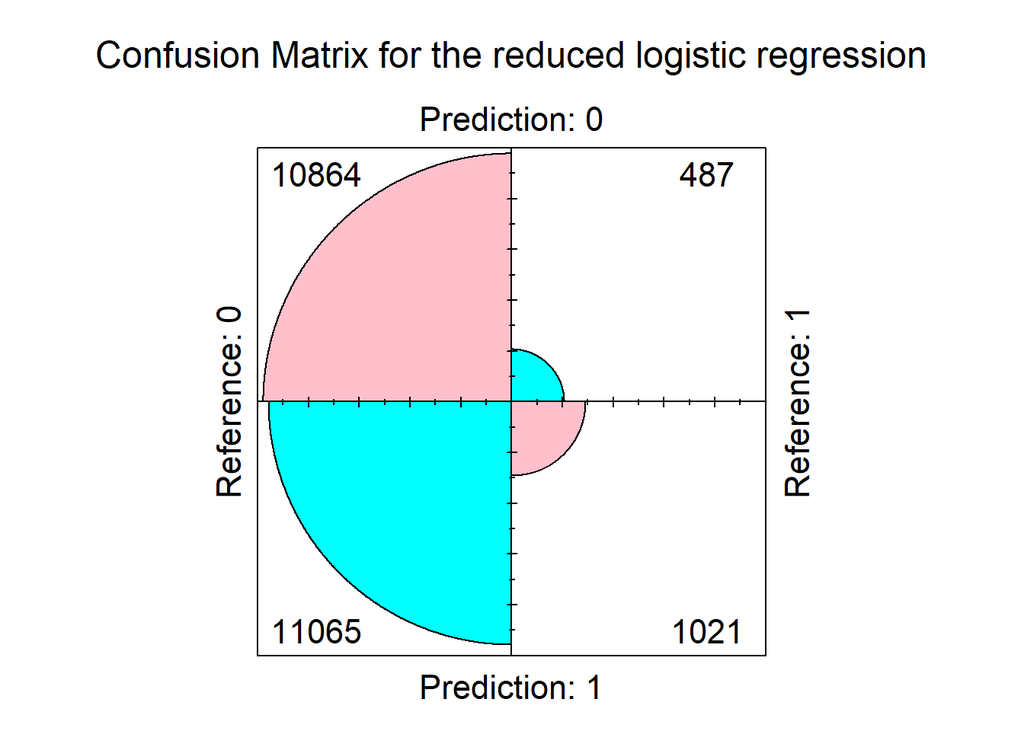

```r
# Backward/Both
cars.lg2 <- glm(is_claim ~ policy_tenure+age_of_car , data= train_downsampling, family=binomial(link="logit"))
pred_logi_back <- predict(cars.lg2, newdata = cars_validation[,-16], type = "response")

# 50% cutoff
logi_outcome_back <- as.data.table(pred_logi_back)
logi_outcome_back <- ifelse(logi_outcome_back > 0.5, 1, 0)

#Confusion Matrix
cm3 <- confusionMatrix(
  factor(logi_outcome_back),
  factor(cars_validation$is_claim),
  positive = "1")
#Plot
fourfoldplot(cm3$table,
             color = c("cyan", "pink"),
             conf.level = 0,
             margin = 1,
             main = "Confusion Matrix for the reduced logistic regression")
```

Reduced model performance metrics

```r
# Accuracy
cm3$overall["Accuracy"]
```

```
##  Accuracy
## 0.5071042
```

```r
#Sensitivity
cm3$byClass["Sensitivity"]
```

```
## Sensitivity
##   0.6770557
```

```r
#Specificity
cm3$byClass["Specificity"]
```

```
## Specificity
##    0.495417
```

Reduced model with the full training dataset instead of the downsample

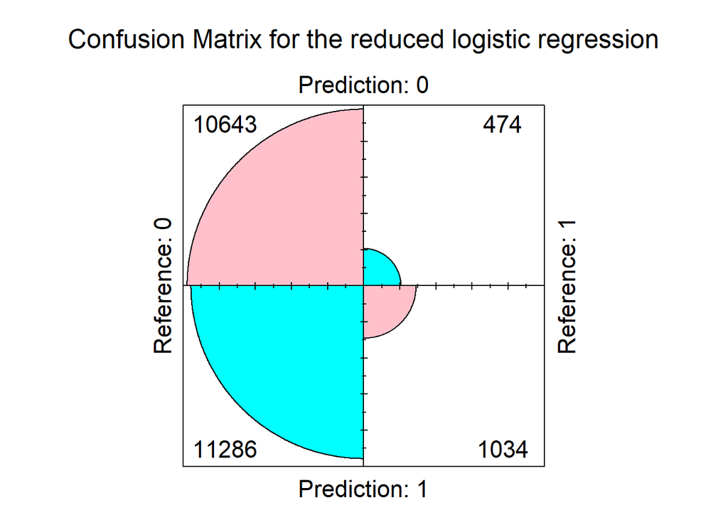

```r
# Backward/Both
cars.lg3 <- glm(is_claim ~ policy_tenure+age_of_car , data= cars_train, family=binomial(link="logit"))
pred_logi_back2 <- predict(cars.lg3, newdata = cars_validation[,-16], type = "response")

# 6% cutoff
logi_outcome_back2 <- as.data.table(pred_logi_back2)
logi_outcome_back2 <- ifelse(logi_outcome_back2 > 0.06, 1, 0)

#Confusion Matrix
cm4 <- confusionMatrix(
  factor(logi_outcome_back2),
  factor(cars_validation$is_claim),
  positive = "1")
#Plot
fourfoldplot(cm4$table,
             color = c("cyan", "pink"),
             conf.level = 0,
             margin = 1,
             main = "Confusion Matrix for the reduced logistic regression")
```

Accuracy

```r
# Accuracy
cm4$overall["Accuracy"]
```

```
##  Accuracy
## 0.4982293
```

Lift Chart

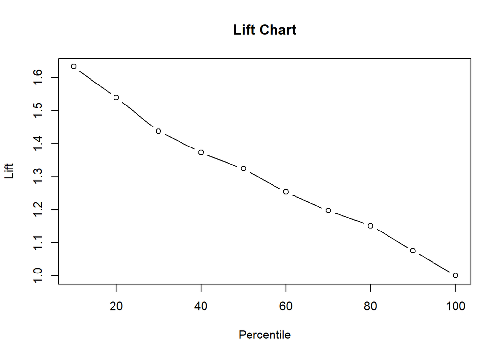

```r
logi_outcome <- as.data.table(pred_logi_back)

liftChart(factor(logi_outcome$pred_logi_back) , factor(cars_validation$is_claim))
```

topdecile

```r
topDecileLift(factor(logi_outcome$pred_logi) , factor(cars_validation$is_claim))
```

```
## [1] 1.631787
```

## Ensemble

### Methods’s application

Extracting probabilities and prediction of each model

```r
#Actual outcome
actual_outcome <- cars_validation[,6]

# Classification Tree
tree.outcome2 <- cbind(as.data.frame(tree.outcome),tree_prob=tree.outcome)
tree.outcome2$tree.outcome <- ifelse(tree.outcome2$tree.outcome>0.5,1,0)
colnames(tree.outcome2) <- c("tree_pred","tree_prob")

#KNN
knn_outcome2 <- as.data.frame(knn_outcome)
colnames(knn_outcome2) <- c("knn_pred", "knn_prob")

#Neural Network
nn_outcome2 <- data.frame(validation_prediction_1H_2N[,1])
nn_outcome2 <- cbind(ifelse(nn_outcome2>=0.5, 1, 0), nn_outcome2)
colnames(nn_outcome2) <- c("nn_pred","nn_prob")

#Logistic Regression
logi_outcome2 <- cbind( logi_outcome, logi_outcome)
colnames(logi_outcome2) <- c("logi_pred","logi_prob")
logi_outcome2$logi_pred <- ifelse(logi_outcome2$logi_pred>0.5,1,0)

ensemble <- data.table(actual_outcome,tree.outcome2,knn_outcome2,nn_outcome2,logi_outcome2)
```

Computing average probability and majority vote

```r
# Average probabilities column
ensemble[, avg_prob := (logi_prob + knn_prob + tree_prob + nn_prob) / 4]

# # Majority vote
ensemble[, maj_vote := as.numeric(as.character(logi_pred))+ as.numeric(as.character(knn_pred)) + as.numeric(as.character(tree_pred))+ as.numeric(as.character(nn_pred))]

ensemble[, maj_vote := ifelse(maj_vote >= 3, 1, 0)]

# Display first 10 rows
kable(ensemble[1:10, ], format = "markdown")
```

| actual_outcome | tree_pred | tree_prob | knn_pred | knn_prob | nn_pred | nn_prob | logi_pred | logi_prob | avg_prob | maj_vote |
| --- | --- | --- | --- | --- | --- | --- | --- | --- | --- | --- |
| 0 | 0 | 0.4017857 | 1 | 0.5365854 | 1 | 0.6152165 | 1 | 0.5708271 | 0.5311037 | 1 |
| 0 | 0 | 0.3828829 | 0 | 0.4390244 | 0 | 0.3818694 | 0 | 0.4878397 | 0.4229041 | 0 |
| 0 | 1 | 0.6216216 | 1 | 0.5609756 | 0 | 0.3818694 | 1 | 0.5849568 | 0.5373559 | 1 |
| 0 | 0 | 0.3182979 | 0 | 0.4146341 | 1 | 0.6839425 | 0 | 0.4431299 | 0.4650011 | 0 |
| 0 | 1 | 0.7042254 | 0 | 0.4878049 | 0 | 0.3821588 | 1 | 0.5955241 | 0.5424283 | 0 |
| 0 | 0 | 0.3043478 | 0 | 0.4634146 | 0 | 0.3818694 | 0 | 0.4770876 | 0.4066799 | 0 |
| 0 | 0 | 0.3182979 | 0 | 0.4634146 | 1 | 0.6839425 | 0 | 0.4260763 | 0.4729328 | 0 |
| 0 | 0 | 0.3182979 | 0 | 0.3658537 | 1 | 0.6839425 | 0 | 0.4547489 | 0.4557107 | 0 |
| 1 | 1 | 0.7042254 | 1 | 0.5365854 | 0 | 0.3818740 | 1 | 0.5183462 | 0.5352577 | 1 |
| 0 | 1 | 0.6216216 | 0 | 0.3902439 | 1 | 0.6839425 | 1 | 0.5064656 | 0.5505684 | 1 |

### Performance Evaluation

Confusion matrix for the average probability approach

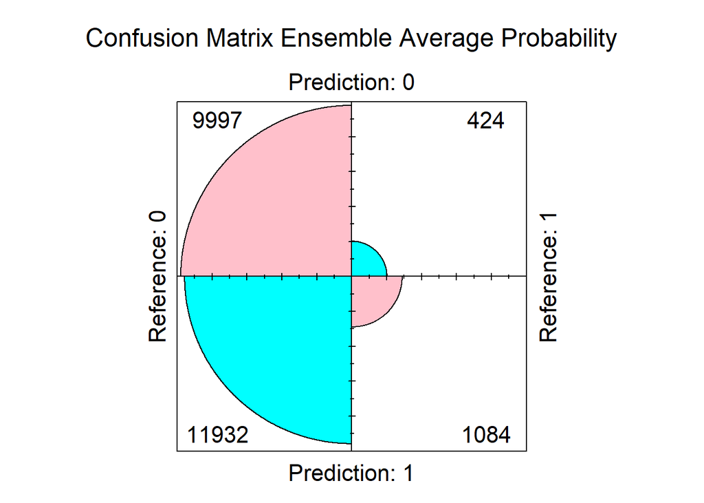

```r
#Confusion Matrix
cm_ens_prob <- confusionMatrix(
  factor(ifelse(ensemble$avg_prob > 0.5, 1 ,0)),
  factor(cars_validation$is_claim),
  positive = "1")
#Plot
fourfoldplot(cm_ens_prob$table,
             color = c("cyan", "pink"),
             conf.level = 0,
             margin = 1,
             main = "Confusion Matrix Ensemble Average Probability")
```

Perfomance metrics average probability

```r
# Accuracy
cm_ens_prob$overall["Accuracy"]
```

```
##  Accuracy
## 0.4727994
```

```r
#Sensitivity
cm_ens_prob$byClass["Sensitivity"]
```

```
## Sensitivity
##   0.7188329
```

```r
#Specificity
cm_ens_prob$byClass["Specificity"]
```

```
## Specificity
##   0.4558803
```

Confusion matrix for the majority vote approach

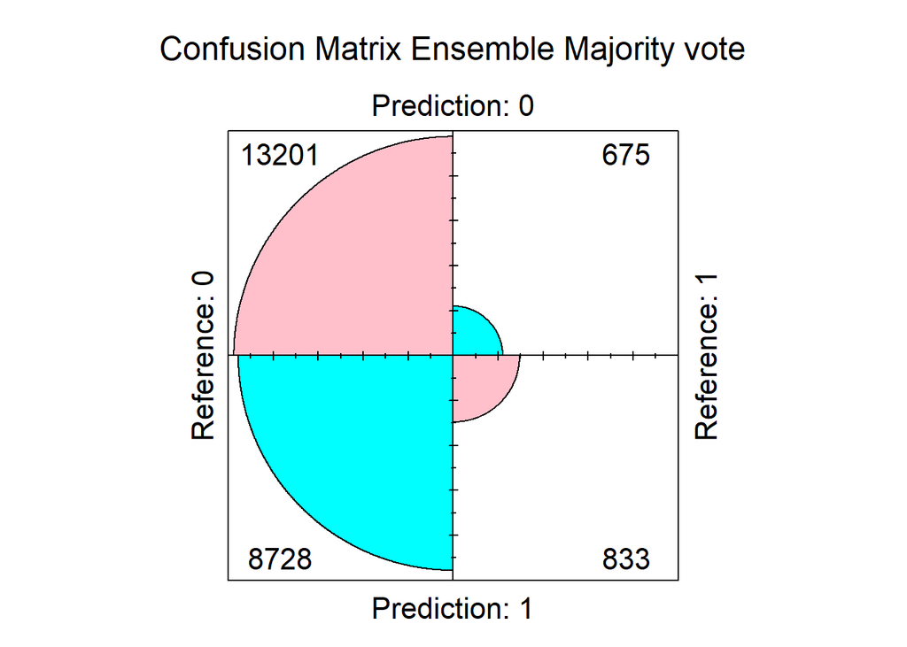

```r
cm_ens_maj <- confusionMatrix(
  factor(ensemble$maj_vote),
  factor(cars_validation$is_claim),
  positive = "1")
#Plot
fourfoldplot(cm_ens_maj$table,
             color = c("cyan", "pink"),
             conf.level = 0,
             margin = 1,
             main = "Confusion Matrix Ensemble Majority vote")
```

Performance metrics majority vote

```r
# Accuracy
cm_ens_maj$overall["Accuracy"]
```

```
##  Accuracy
## 0.5987968
```

```r
#Sensitivity
cm_ens_maj$byClass["Sensitivity"]
```

```
## Sensitivity
##   0.5523873
```

```r
#Specificity
cm_ens_maj$byClass["Specificity"]
```

```
## Specificity
##   0.6019882
```

# All methods comparison

Overall, we are interested in a balance between Sensitivity and Specificity as we need to identify correctly claimed files, but also to avoid mistakes in negatives predictions. The situation is tricky since that situation corresponds to a trade-off. Accepting a little decrease in specificity would provide a lot of misclassified negative outcomes given the commonness of that class. On the other hand, accepting a little decrease in sensitivity would goe against or goal.

## overall Accuracy

```r
Accuracy <-  data.frame(LR = round(cm3$overall[1],3))  #predict accuracy by using logistic regression
Accuracy <- cbind(Accuracy, KNN = round(cmk$overall[1],3))      #predict accuracy by using KNN
Accuracy <- cbind(Accuracy,CT = round(conf_matrix_tree_v$overall[1],3))    #predict accuracy by using tree
Accuracy <- cbind(Accuracy,NN=round(conf_matrix_1H2N_valid$overall[1],3))     #predict accuracy by using neural network
Accuracy <- cbind(Accuracy,EM=round(cm_ens_maj$overall[1],3))     #predict accuracy ensemble majority
Accuracy <- cbind(Accuracy,EA=round(cm_ens_prob$overall[1],3))     #predict accuracy ensemble average

Accuracy.melt = melt(Accuracy)
```

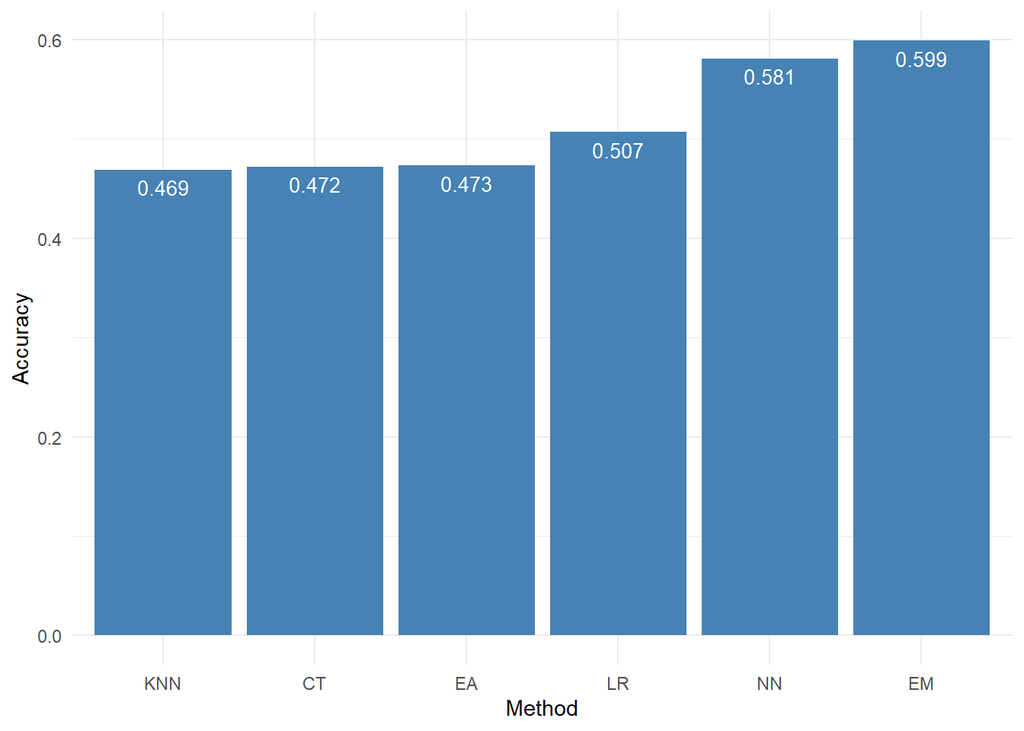

```r
ggplot(data = Accuracy.melt,aes(x=reorder(variable, value),y=value))+
  ylab("Accuracy") +
  xlab("Method") +
  geom_bar(stat="identity", fill="steelblue")+
  geom_text(aes(label=value), vjust=1.6, color="white", size=3.5)+
  theme_minimal()
```

## overall Specificity

```r
Specificity_P <-  data.frame(LR = round(cm2$byClass[2],3))  #predict specificity by using logistic regression
Specificity_P <- cbind(Specificity_P, KNN = round(cmk$byClass[2],3))       #predict specificity by using KNN
Specificity_P <- cbind(Specificity_P,CT = round(conf_matrix_tree_v$byClass[2],3))     #predicts specificity tree
Specificity_P <- cbind(Specificity_P,NN=round(conf_matrix_1H2N_valid$byClass[2],3))    #predict specificity neural network
Specificity_P <- cbind(Specificity_P,EM=round(cm_ens_maj$byClass[2],3))    #predict specificity majority voting
Specificity_P <- cbind(Specificity_P,EA=round(cm_ens_prob$byClass[2],3))    #predict specificity ensemble average

Specificity_P.melt = melt(Specificity_P)
```

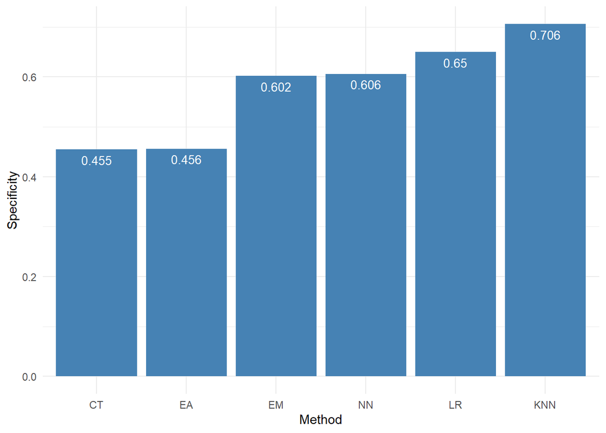

```r
ggplot(data = Specificity_P.melt,aes(x=reorder(variable, value),y=value))+
  ylab("Specificity") +
  xlab("Method") +
  geom_bar(stat="identity", fill="steelblue")+
  geom_text(aes(label=value), vjust=1.6, color="white", size=3.5)+
  theme_minimal()
```

## overall Sensitivity

```r
Sensitivity <-  data.frame(LR = round(cm2$byClass[1],3))  #predict Sensitivity by using logistic regression
Sensitivity <- cbind(Sensitivity, KNN = round(cmk$byClass[1],3))       #predict Sensitivity by using KNN
Sensitivity <- cbind(Sensitivity,CT = round(conf_matrix_tree_v$byClass[1],3))     #predicts Sensitivity  tree
Sensitivity <- cbind(Sensitivity,NN=round(conf_matrix_1H2N_valid$byClass[1],3))    #predict Sensitivity  neural network
Sensitivity <- cbind(Sensitivity,EM=round(cm_ens_maj$byClass[1],3))    #predict Sensitivity majority voting
Sensitivity <- cbind(Sensitivity,EA=round(cm_ens_prob$byClass[1],3))    #predict Sensitivity ensemble average

Sensitivity.melt = melt(Sensitivity)
```

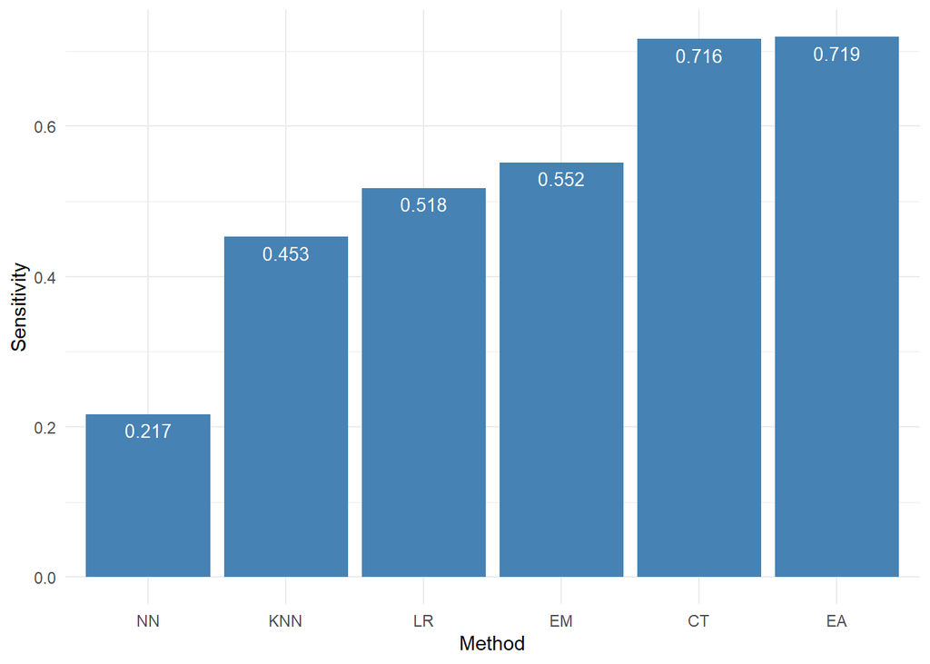

```r
ggplot(data = Sensitivity.melt,aes(x=reorder(variable, value),y=value)) +
  ylab("Sensitivity") +
  xlab("Method") +
  geom_bar(stat="identity", fill="steelblue")+
  geom_text(aes(label=value), vjust=1.6, color="white", size=3.5)+
  theme_minimal()
```